# Hay calentamiento global?

Carguemos los paquetes necesarios

```python
%pylab inline
import pandas as pd
from scipy import interpolate
```

Carguemos los datos

```python
df = pd.read_csv('Calentamientoglobal.csv')
```

Convirtamos cada ciudad en un dataframe

```python
bog = df[df.ciudad == "Bogota"]
cal = df[df.ciudad == "Cali"]
buc = df[df.ciudad == "Bucaramanga"]
bar = df[df.ciudad == "Barranquilla"]
ipi = df[df.ciudad == "Ipiales"]
```

Eliminando columnas innecesarias

```python
del bog['anio']
del bog['mes']
del bog['ciudad']
del cal['anio']
del cal['mes']
del cal['ciudad']
del buc['anio']
del buc['mes']
del buc['ciudad']
del bar['anio']
del bar['mes']
del bar['ciudad']
del ipi['anio']
del ipi['mes']
del ipi['ciudad']
```

Convirtiendo de Pandas a listas para poder grafiar con matplotlib

```python
bogts = bog['fecha'].tolist()
bogtsint = linspace(0,len(bogts),len(bogts))
bogdat = bog['temperatura'].tolist()

calts = cal['fecha'].tolist()
caltsint = linspace(0,len(calts),len(calts))
caldat = cal['temperatura'].tolist()

bucts = buc['fecha'].tolist()
buctsint = linspace(0,len(bucts),len(bucts))
bucdat = buc['temperatura'].tolist()

barts = bar['fecha'].tolist()
bartsint = linspace(0,len(barts),len(barts))
bardat = bar['temperatura'].tolist()

ipits = ipi['fecha'].tolist()
ipitsint = linspace(0,len(ipits),len(ipits))
ipidat = ipi['temperatura'].tolist()
```

## Miremos el cambio de temperatura para 5 ciudades diferentes de Colombia

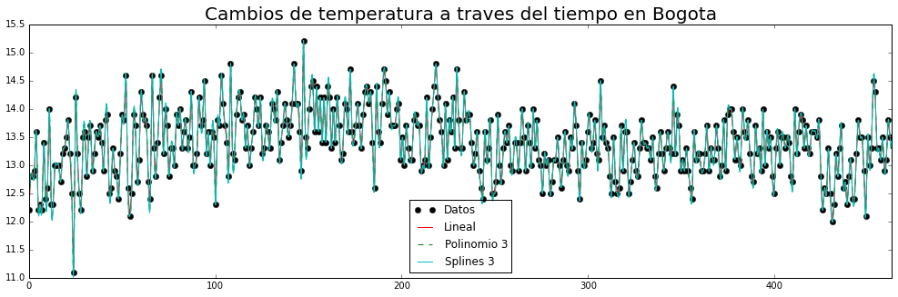

```python
#para bogota
figure(figsize=(17,5))
f = interpolate.interp1d(bogtsint,bogdat)
f2 = interpolate.interp1d(bogtsint,bogdat,kind='cubic')
tck = interpolate.splrep(bogtsint,bogdat, s=0)
xnew = np.arange(0,len(bogts),0.1)
f3 = interpolate.splev(xnew, tck, der=0)
plt.plot(bogtsint,bogdat, "ko",xnew,f(xnew),'-r',xnew,f2(xnew),'--g',xnew,f3,'c')
legend(['Datos', 'Lineal', 'Polinomio 3' ,'Splines 3'], loc='best')
xlim(0,len(bogts))
title('Cambios de temperatura a traves del tiempo en Bogota', fontsize=20)
```

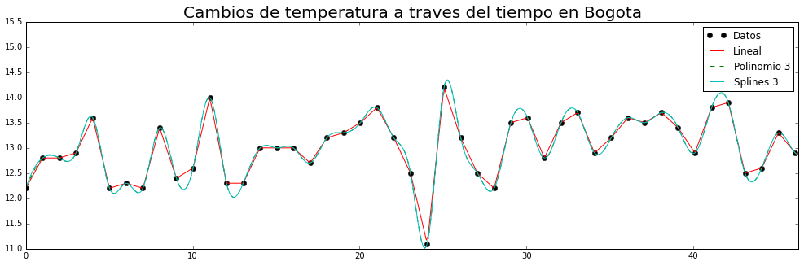

```python
#bogota zoom
figure(figsize=(17,5))
f = interpolate.interp1d(bogtsint,bogdat)
f2 = interpolate.interp1d(bogtsint,bogdat,kind='cubic')
tck = interpolate.splrep(bogtsint,bogdat, s=0)
xnew = np.arange(0,len(bogts),0.1)
f3 = interpolate.splev(xnew, tck, der=0)
plt.plot(bogtsint,bogdat, "ko",xnew,f(xnew),'-r',xnew,f2(xnew),'--g',xnew,f3,'c')
legend(['Datos', 'Lineal', 'Polinomio 3' ,'Splines 3'], loc='best')
xlim(0,0.1*len(bogts))
title('Cambios de temperatura a traves del tiempo en Bogota', fontsize=20)
```

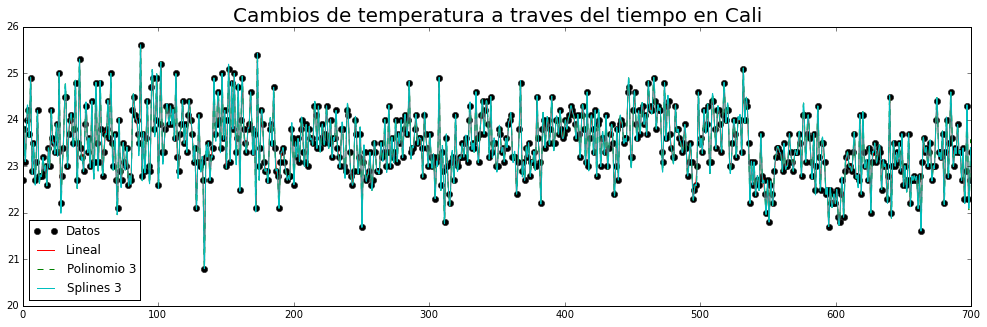

```python
# para Cali
figure(figsize=(17,5))
f = interpolate.interp1d(caltsint,caldat)
f2 = interpolate.interp1d(caltsint,caldat,kind='cubic')
tck = interpolate.splrep(caltsint,caldat, s=0)
xnew = np.arange(0,len(calts),0.1)
f3 = interpolate.splev(xnew, tck, der=0)
plt.plot(caltsint,caldat, "ko",xnew,f(xnew),'-r',xnew,f2(xnew),'--g',xnew,f3,'c')
legend(['Datos', 'Lineal', 'Polinomio 3' ,'Splines 3'], loc='best')
xlim(0,len(calts))
title('Cambios de temperatura a traves del tiempo en Cali', fontsize=20)
```

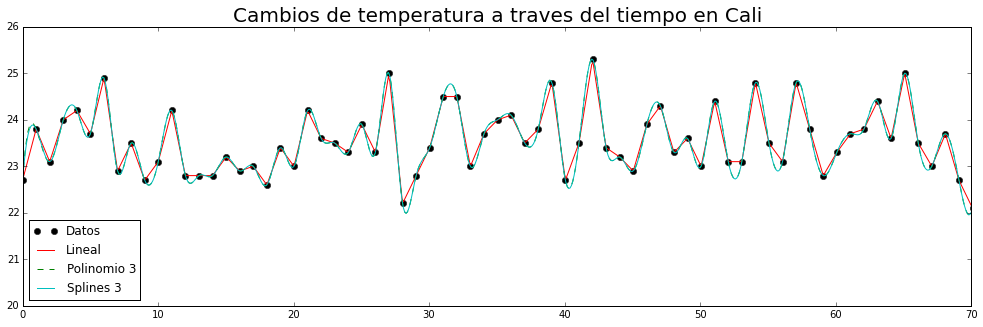

```python
#Zoom Cali
figure(figsize=(17,5))
f = interpolate.interp1d(caltsint,caldat)
f2 = interpolate.interp1d(caltsint,caldat,kind='cubic')
tck = interpolate.splrep(caltsint,caldat, s=0)
xnew = np.arange(0,len(calts),0.1)
f3 = interpolate.splev(xnew, tck, der=0)
plt.plot(caltsint,caldat, "ko",xnew,f(xnew),'-r',xnew,f2(xnew),'--g',xnew,f3,'c')
legend(['Datos', 'Lineal', 'Polinomio 3' ,'Splines 3'], loc='best')
xlim(0,0.1*len(calts))
title('Cambios de temperatura a traves del tiempo en Cali', fontsize=20)
```

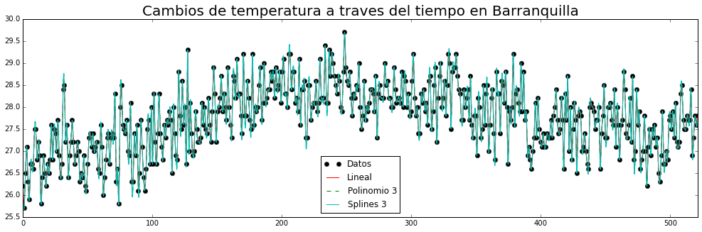

```python
#para barranquilla
figure(figsize=(17,5))
f = interpolate.interp1d(bartsint,bardat)
f2 = interpolate.interp1d(bartsint,bardat,kind='cubic')
tck = interpolate.splrep(bartsint,bardat, s=0)
xnew = np.arange(0,len(barts),0.1)
f3 = interpolate.splev(xnew, tck, der=0)
plt.plot(bartsint,bardat, "ko",xnew,f(xnew),'-r',xnew,f2(xnew),'--g',xnew,f3,'c')
legend(['Datos', 'Lineal', 'Polinomio 3' ,'Splines 3'], loc='best')
xlim(0,len(barts))
title('Cambios de temperatura a traves del tiempo en Barranquilla', fontsize=20)
```

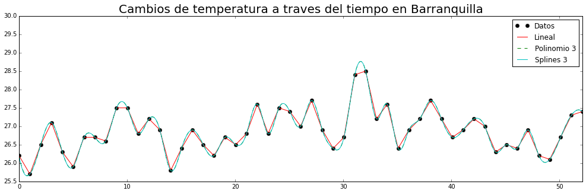

```python
#zoom Barranquilla
figure(figsize=(17,5))
f = interpolate.interp1d(bartsint,bardat)
f2 = interpolate.interp1d(bartsint,bardat,kind='cubic')
tck = interpolate.splrep(bartsint,bardat, s=0)
xnew = np.arange(0,len(barts),0.1)
f3 = interpolate.splev(xnew, tck, der=0)
plt.plot(bartsint,bardat, "ko",xnew,f(xnew),'-r',xnew,f2(xnew),'--g',xnew,f3,'c')
legend(['Datos', 'Lineal', 'Polinomio 3' ,'Splines 3'], loc='best')
xlim(0,0.1*len(barts))
title('Cambios de temperatura a traves del tiempo en Barranquilla', fontsize=20)
```

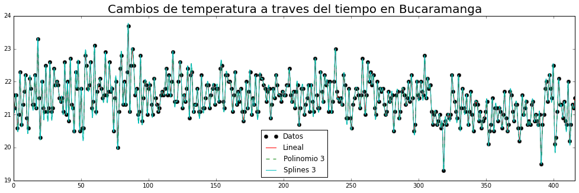

```python
#Para Bucaramanga
figure(figsize=(17,5))
f = interpolate.interp1d(buctsint,bucdat)
f2 = interpolate.interp1d(buctsint,bucdat,kind='cubic')
tck = interpolate.splrep(buctsint,bucdat, s=0)
xnew = np.arange(0,len(bucts),0.1)
f3 = interpolate.splev(xnew, tck, der=0)
plt.plot(buctsint,bucdat, "ko",xnew,f(xnew),'-r',xnew,f2(xnew),'--g',xnew,f3,'c')
legend(['Datos', 'Lineal', 'Polinomio 3' ,'Splines 3'], loc='best')
xlim(0,len(bucts))
title('Cambios de temperatura a traves del tiempo en Bucaramanga', fontsize=20)
```

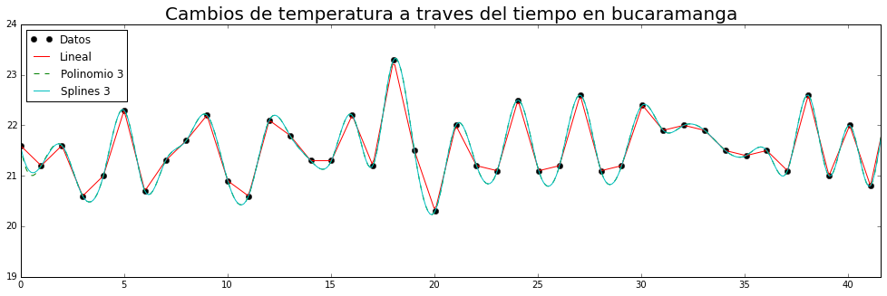

```python
#zoom bucaramanga
figure(figsize=(17,5))
f = interpolate.interp1d(buctsint,bucdat)
f2 = interpolate.interp1d(buctsint,bucdat,kind='cubic')
tck = interpolate.splrep(buctsint,bucdat, s=0)
xnew = np.arange(0,len(bucts),0.1)
f3 = interpolate.splev(xnew, tck, der=0)
plt.plot(buctsint,bucdat, "ko",xnew,f(xnew),'-r',xnew,f2(xnew),'--g',xnew,f3,'c')
legend(['Datos', 'Lineal', 'Polinomio 3' ,'Splines 3'], loc='best')
xlim(0,0.1*len(bucts))
title('Cambios de temperatura a traves del tiempo en bucaramanga', fontsize=20)
```

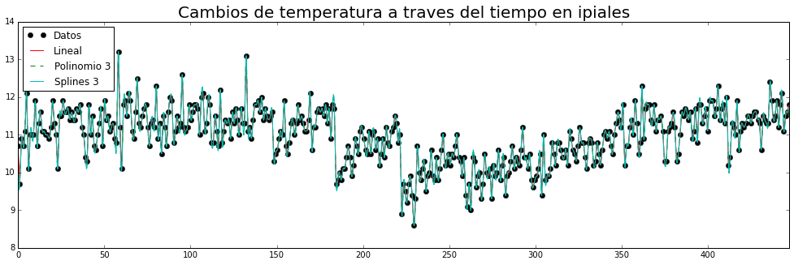

```python
#para Ipiales
figure(figsize=(17,5))
f = interpolate.interp1d(ipitsint,ipidat)
f2 = interpolate.interp1d(ipitsint,ipidat,kind='cubic')
tck = interpolate.splrep(ipitsint,ipidat, s=0)
xnew = np.arange(0,len(ipits),0.1)
f3 = interpolate.splev(xnew, tck, der=0)
plt.plot(ipitsint,ipidat, "ko",xnew,f(xnew),'-r',xnew,f2(xnew),'--g',xnew,f3,'c')
legend(['Datos', 'Lineal', 'Polinomio 3' ,'Splines 3'], loc='best')
xlim(0,len(ipits))
title('Cambios de temperatura a traves del tiempo en ipiales', fontsize=20)
```

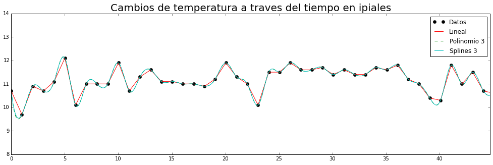

```python
#Zoom ipiales
figure(figsize=(17,5))
f = interpolate.interp1d(ipitsint,ipidat)
f2 = interpolate.interp1d(ipitsint,ipidat,kind='cubic')
tck = interpolate.splrep(ipitsint,ipidat, s=0)
xnew = np.arange(0,len(ipits),0.1)
f3 = interpolate.splev(xnew, tck, der=0)
plt.plot(ipitsint,ipidat, "ko",xnew,f(xnew),'-r',xnew,f2(xnew),'--g',xnew,f3,'c')
legend(['Datos', 'Lineal', 'Polinomio 3' ,'Splines 3'], loc='best')
xlim(0,0.1*len(ipits))
title('Cambios de temperatura a traves del tiempo en ipiales', fontsize=20)
```

Una cosa que hay que tener en cuenta es que la interpolacion por splines suelen ser preferida sobre la interpolacion polinomica pues a medida que se aumenta el orden del polinomio este tiende a oscilar de manera "innecesaria" a continuacion se muestra dicho fenomeno.

[figure not shown]

```python
#bogota zoom
figure(figsize=(17,5))
f = interpolate.interp1d(bogtsint,bogdat)
f2 = interpolate.interp1d(bogtsint,bogdat,kind='quadratic')
tck = interpolate.splrep(bogtsint,bogdat, s=0)
xnew = np.arange(0,len(bogts),0.1)
f3 = interpolate.splev(xnew, tck, der=0)
plt.plot(bogtsint,bogdat, "ko",xnew,f(xnew),'-r',xnew,f2(xnew),'--g',xnew,f3,'c')
legend(['Datos', 'Lineal', 'Polinomio 4' ,'Splines 3'], loc='best')
xlim(20,30)
title('Cambios de temperatura a traves del tiempo en Bogota', fontsize=20)
```

Por otro lado la interpolacion lineal no es la óptima para este tipo de datos, pues los cambios de temperatura ocurren como procesos continuos. De manera que el mejor se debe escoger entre el spline y el polinomio (de grado correcto) siendo exagerados se puede ver a continuacion que el ajuste para splines es el mismo que el polinomico. Y por tanto no se puede determinar cual de los se ajusta mejor a los datos.

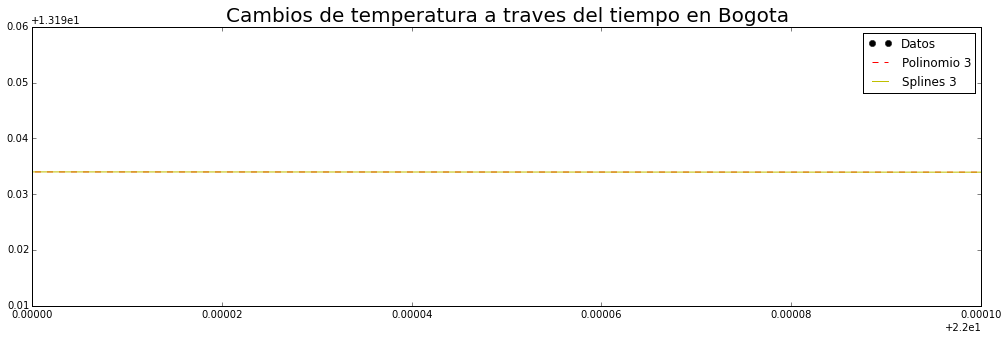

```python
#bogota zoom
figure(figsize=(17,5))
f2 = interpolate.interp1d(bogtsint,bogdat,kind='cubic')
tck = interpolate.splrep(bogtsint,bogdat, s=0)
xnew = np.arange(0,len(bogts),0.1)
f3 = interpolate.splev(xnew, tck, der=0)
plt.plot(bogtsint,bogdat, "ko",xnew,f2(xnew),'--r',xnew,f3,'y')
legend(['Datos', 'Polinomio 3' ,'Splines 3'], loc='best')
xlim(22,22.0001)
ylim(13.2,13.25)
title('Cambios de temperatura a traves del tiempo en Bogota', fontsize=20)
```

```python
mean(bogdat), std(bogdat)
```

```
(13.391792656587473, 0.57192942384878298)
```

```python
mean(caldat), std(caldat)
```

```
(23.454285714285714, 0.66575107194500138)
```

```python
mean(bucdat), std(bucdat)
```

```
(21.491826923076925, 0.60580566892850807)
```

```python
mean(bardat), std(bardat)
```

```
(27.748752399232242, 0.74710148680894239)
```

```python
mean(ipidat), std(ipidat)
```

```
(10.971140939597314, 0.70877800458118634)
```